# Paka Tagging Paper

#### Loading in all libraries.

###### Importing principle dependencies

```r
# install.packages('marmap')
library('marmap') # bathymetry()
# install.packages('lubridate')
library('lubridate') # floor_date(), ceil_date()
# install.packages('doParallel')
library('doParallel') # foreach()
# install.packages('beepr')
library('beepr') # beep
# install.packages('dplyr')
library('dplyr') # filter()
# install.packages('useful')
library('useful') # compare.list()
# install.packages('RAtmosphere')
library('RAtmosphere')
# install.packages('geosphere')
library('geosphere') # areaPolygon(), # distGeo() Note: wrapped in old lldist function
# install.packages('igraph')
library('igraph') # graph.adjacency()
# install.packages('notifyR')
library('notifyR') # send_push()
# install.packages('png')
library('png')
# install.packages('lunar')
library('lunar') # lunar.phase()
# install.packages('suncalc')
library('suncalc') # getSunlightTimes
# install.packages('data.table')
library('data.table') # uniqueN
# install.packages('lattice')
library('lattice')
# install.packages('ncdf4')
library('ncdf4') #nc_open()
# install.packages('xts')
library('xts')
registerDoParallel(cores = 7)
```

Loading in our data

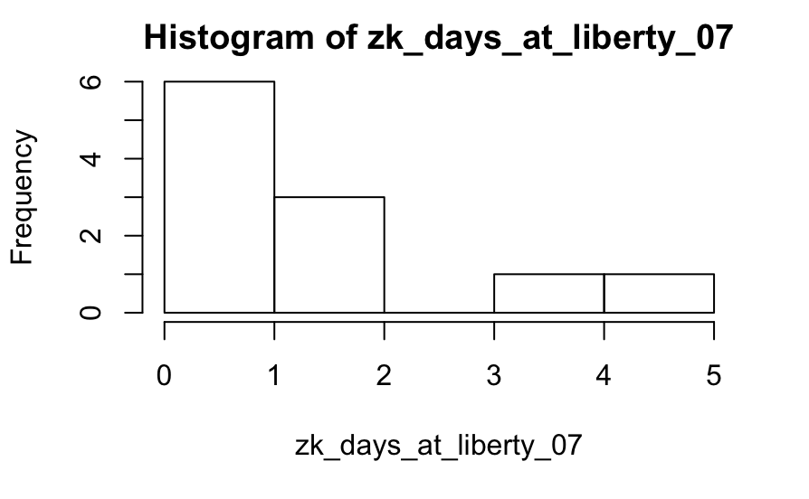

#### How many receiver stations were recovered?

How many receiver stations did we recover in the last analysis period of the project

```
[1] 39
```

#### Calculating Habitat Size

Adult bottomfish habitat is defined as waters with depths between 100 and 400 m. We want to know how much habitat area is available in BRFA E.

```r
brfa_e_bathy = get_bathymetry(region = 'Makapuu', resolution = "medium")
brfa_e_bathy = subsetBathy(brfa_e_bathy, x = c(convert_lat_lon(-157, 41), convert_lat_lon(-157, 32)), y = c( convert_lat_lon(21, 25), convert_lat_lon(21, 17)), locator = FALSE)
area_sq_km = get.area(brfa_e_bathy, level.inf = -400, level.sup = -100)$Square.Km
```

### Shark Info

```r
shark_tags
```

[output not shown]

#### Getting Period of Analysis

We need to decide what our analysis period is. To make comparisons between fish, we need to limit our analysis to a specific period. We will use the period of maximum receivers. This period began sometime in June 2017.

```r
period_start = as.POSIXct('2017-06-26') # first day after receiver array went in water
print(period_start)
```

```
[1] "2017-06-26 HST"
```

Similarly we know that we want to end the analysis period when the first receiver was pulled from the water (or in this case, when 338 broke it’s mooring.) This occurred sometime in spring 2018.

```r
period_end = min(receiver_data$recovery_date[receiver_data$recovery_date >= as.POSIXct('2018-01-01')], na.rm = TRUE)
print(period_end)
```

```
[1] "2018-04-15 HST"
```

#### Tag Status

In this section we will count the total number of fish tagged, determine their status, and print out some 6 pannel plots to confirm those statuses.

Let’s first eliminate any detections that have been flagged as potentially false

```r
vue_data = vue_data[vue_data$detection_status == TRUE, ]
```

Now we run our data through our mortality algorthm to catagorize status and subset out just the opakapaka

```r
track_status_all = determine_track_status(vue_df = vue_data, bathymetry = get_bathymetry('mhi', 'low'))
```

Which of these “valid” tags were detected in our analysis period. Run our analysis on this and make six pannel plots for each so we can validate

```r
print(track_status$tag_id[track_status$status == 'Alive' & track_status$tag_id %in% unique(vue_data$tag_id[vue_data$datetime >= period_start])])
```

```
 [1] "12"    "2122"  "2127"  "2133"  "2136"  "2139"  "2140"  "2157"  "28179"
[10] "30684" "30685" "30705" "30721" "30729" "36808" "36809" "36811" "36812"
[19] "36814" "36815" "36816" "36818" "51582" "51586" "51588" "51595" "51596"
[28] "51600" "6"     "61385" "61389" "927"
```

How many tags did we put out?

```r
tagged_ids = unique(tagging_data$vem_tag_id[tagging_data$datetime >= as.POSIXct('2017-01-09') & tagging_data$species == "Opakapaka"])
length(tagged_ids)
```

Lets see whats alive

```r
valid_tags = track_status$tag_id[track_status$status == 'Alive' & track_status$tag_id %in% tagging_data$vem_tag_id[tagging_data$species == 'Opakapaka']]
```

```r
length(valid_tags)
```

```
[1] 10
```

Calculating survivorship

```r
length(c(questionable_tags, valid_tags)) / length(c(valid_tags, questionable_tags, dead_tags, excluded_tags))
```

```
[1] 0.2383721
```

Getting Tagging info

```r
  ## What was the minimum tagging date of our valid fish
  min(tagging_data$datetime[tagging_data$vem_tag_id %in% valid_tags])

  ## Earliest reported tagging date
    start_tagging_date = as.POSIXct('2017-01-09')

  ## How many opakapaka were tagged after that date?
    length(tagging_data$unique_id[tagging_data$datetime >= start_tagging_date & tagging_data$species == 'Opakapaka'])

  ## How many tags were detected on the array?
  length(unique(vue_data$tag_id[vue_data$datetime >= '2017-06-26' & vue_data$tag_id %in% unique(tagging_data$vem_tag_id[tagging_data$species == 'Opakapaka'])]))

  ## How many tags detected were 'valid'
length(valid_tags)

  ## How many tags detected were 'questionable'
   length(questionable_tags)

  ## How many tags are straight up dead?
   length(dead_tags)

  ## How many tags were excluded?
   length(excluded_tags)

  ## How many tags never appeared on the array?
   length(never_detected)

  vue_data = vue_data[vue_data$datetime >= start_date & vue_data$datetime < end_date, ]
```

Running our analyses

```r
valid_data = run(run_description = "Spring 2018 - Valid Track Data without Plots",
                      vue_df = vue_data,
                      receiver_df = receiver_data,
                      tagging_df = tagging_data,
                      start_date = as.POSIXct('2017-06-26'),
                      end_date = as.POSIXct('2018-04-15'),
                      region = "Makapuu",
                      plot = FALSE,
                      tag_ids = valid_tags
)
```

```
[1] "Let's Do This."
```

[output not shown]

#### Calculating tagging date range for fish

```r
range(phase_10_valid$tagging_date$tagging_date)

## Subset tagging data
subset_tagging_data = tagging_data[tagging_data$datetime >= floor_date(min(range(phase_10_valid$tagging_date$tagging_date)), unit = 'day') & tagging_data$species == "Opakapaka" & !is.na(tagging_data$vem_tag_id), ]

## How many individuals tagged?
length(subset_tagging_data$unique_id) -1 # Note on tag 925 indicates individual was dead.

## How many individuals tagged with pressure tags?
length(which(tolower(subset_tagging_data$vem_tag_type) == 'v13p')) - 13

## How were these fish tagged?
aggergate(subset_tagging_data$vem_tag_id, by = list(subset_tagging_data$release_method), FUN = length)

## How many of these fish ended up super dead?
track_status = determine_track_status(vue_df = vue_data[vue_data$tag_id %in% subset_tagging_data$vem_tag_id, ])

## How many fish showed up on the array?
length(which(subset_tagging_data$vem_tag_id %in% vue_data$tag_id))

## How many Pressure tags showed up on the array?
length(which(subset_tagging_data$vem_tag_id[tolower(subset_tagging_data$vem_tag_type) == 'v13p'] %in% vue_data$tag_id))

## What was transmission interval of tags?
unique(tag_specs$min_interval_sec[tag_specs$tag_id %in% subset_tagging_data$vem_tag_id])

unique(tag_specs$max_interval_sec[tag_specs$tag_id %in% subset_tagging_data$vem_tag_id])
```

How many fish were tagged total in this period?

```r
tagging_data.period = tagging_data[tagging_data$datetime >= as.POSIXct('2017-01-9') & tagging_data$species == "Opakapaka", ]
dim(tagging_data.period)[1]
```

How many tags were detected on the array in this period?

```r
tagging_data.detected = tagging_data.period[tagging_data.period$vem_tag_id %in% vue_data$tag_id[vue_data$datetime >= period_start], ]

dim(tagging_data.detected)[1]
```

How many were pressure tags?

```r
length(which(tagging_data.detected$vem_tag_type == 'V13P'))
```

How many fish of each status?

```r
length(which(track_status.detected$status == "Alive"))

length(which(track_status.detected$status == "Questionable"))

length(which(track_status.detected$status == "Dead"))

length(which(track_status.detected$status == "Excluded From Analysis"))
```

How many fish never detected?

```r
length(unique(tagging_data.period$vem_tag_id)) - length(unique(tagging_data.detected$vem_tag_id))
```

What was survivorship rate for tags minus tags with insufficent data

```r
length(valid) / length(track_status$tag_id[track_status$tag_id %in% tagging_data.detected$vem_tag_id & track_status$status != "Excluded From Analysis"])
```

### Getting results for each run scenario

| tag_id | min_date | max_date | days_at_liberty |
| --- | --- | --- | --- |
| 2133 | 2018-01-10 | 2018-02-06 | 28 |
| 2136 | 2018-01-10 | 2018-04-09 | 90 |
| 28179 | 2018-01-12 | 2018-04-15 | 94 |
| 30684 | 2017-08-28 | 2018-04-15 | 231 |
| 30705 | 2017-08-30 | 2018-04-15 | 229 |
| 30721 | 2017-06-26 | 2018-04-15 | 294 |
| 51582 | 2017-06-26 | 2018-04-02 | 281 |
| 51586 | 2017-06-26 | 2018-04-15 | 294 |
| 51588 | 2017-06-26 | 2017-12-28 | 186 |
| 51596 | 2017-08-28 | 2018-04-15 | 231 |

#### Testing Receiver Fence Robustness

We are going to test the robustness of our receiver gates by looking at the detection rate of a sync tag (located within one of our VR2ARs) at a receiver station located a fixed distance away.

```r
plot_receiver_map(receiver_data, receiver_numbers = TRUE, save_plot = FALSE)
```

```r
tag_id = 61375 # From receiver "Oahu - Makapuu BRFA 336"
station_id = "Oahu - Makapuu BRFA 14"
receiver_id = receiver_data$vr2w_serial[which(receiver_data$station_name == station_id & receiver_data$deployment_date > as.POSIXct('2017-06-01') & !is.na(receiver_data$recovery_date))]
vue_df = raw_vue_data
vue_df = vue_df[vue_df$datetime > fy2018 & vue_df$tag_id == tag_id & vue_df$receiver == receiver_id, ]
vue_df = clean_vue_data(vue_df, receiver_data)
dist = distance_between_receivers(receiver_df = receiver_data, start_date = fy2018)
dist['Oahu - Makapuu BRFA 14', "Oahu - Makapuu BRFA 336"] * 1000 # m
  print(paste('Station 14 and Station 336 are', round(dist['Oahu - Makapuu BRFA 14', "Oahu - Makapuu BRFA 336"] * 1000, digits = 0), 'm from one another', sep = " "))
```

It would be helpful to understand how far apart fence receivers are in space. We should look at the maximum distance between any two nodes in each of the four fences to understand the space relationships between subsequent nodes.

Note that because detection envelopes are probability distributions, detection probability is additive when detection envelopes overlap. Therefore the distance between two subsequent receivers is usefull, but half that distance (the midpoint between two receivers), is what we will actually look at to understand detection rates

```r
 ## Which receivers were parts of fence?
  outside_north = paste('Oahu - Makapuu BRFA', c(5, 4, 3, 2))
  outside_south = paste('Oahu - Makapuu BRFA', c(311, 312, 313, 314, 315, 316, 317, 318, 319, 320))
  inside_north = paste('Oahu - Makapuu BRFA', c(331, 332, 333))
  inside_south = paste('Oahu - Makapuu BRFA', c(334, 335, 336, 337, 338, 339, 340, 341))

  ## How far apart were receivers spaced?
  outside_north_receiver_dist_mat = distance_between_receivers(receiver_data[receiver_data$station_name %in% outside_north, ], start_date = fy2018, end_date = fy2018 + (24*60*60), include_lost = TRUE)
    range(apply(outside_north_receiver_dist_mat$matrix, 1, min, na.rm = TRUE))

  outside_south_receiver_dist_mat = distance_between_receivers(receiver_data[receiver_data$station_name %in% outside_south, ], start_date = fy2018, end_date = fy2018 + (24*60*60), include_lost = TRUE)
    range(apply(outside_south_receiver_dist_mat$matrix, 1, min, na.rm = TRUE))

  inside_north_receiver_dist_mat = distance_between_receivers(receiver_data[receiver_data$station_name %in% inside_north, ], start_date = fy2018, end_date = fy2018 + (24*60*60), include_lost = TRUE)
    range(apply(inside_north_receiver_dist_mat$matrix, 1, min, na.rm = TRUE))

  inside_south_receiver_dist_mat = distance_between_receivers(receiver_data[receiver_data$station_name %in% inside_south, ], start_date = fy2018, end_date = fy2018 + (24*60*60), include_lost = TRUE)
    range(apply(inside_south_receiver_dist_mat$matrix, 1, min, na.rm = TRUE))

  ## Which fence nodes were lost? When?
  View(receiver_data[receiver_data$recovered != "" & receiver_data$recovery_date >= fy2018 & receiver_data$deployment_date <= fy2018, ])
  View(receiver_data[receiver_data$station_name == 'Oahu - Makapuu BRFA 338', ])

  ## What does this mean for detection?
  inside_south_recovered_receiver_dist_mat = distance_between_receivers(receiver_data[receiver_data$station_name %in% inside_south & receiver_data$recovered == "", ], start_date = fy2018, end_date = fy2018 + (24*60*60), include_lost = TRUE)
  max_dist_between_is_fence_receivers = max(apply(inside_south_recovered_receiver_dist_mat$matrix, 1, min, na.rm = TRUE))
    max_dist_between_is_fence_receivers / 2
```

From our range testing results, we know that at 827 m, we should have an aproximate detection rate of 6.06 %. Let’s look at how many periods we had such a detection rate. We need to define how long each period is, the number of transmissions sent during each period and the number of those transmissions that were detected.

```r
## Binning hours into periods
hours_per_bin = 2
hourbins = seq.POSIXt(from = as.POSIXct('2017-08-30'), to = max(vue_df$datetime), by = 'hours')
  hourbins = hourbins[seq(from = 1, to = length(hourbins), by = hours_per_bin)]

## Calculating sent transmissions per period
  transmissions_per_hour = 6 * hours_per_bin

## Counting the number of detections from sync tag detected by station hourly
hourly_self_detections = c()
for(i in 1:length(hourbins)){
  hourly_self_detections = c(hourly_self_detections, length(vue_df$datetime[vue_df$datetime >= hourbins[i] & vue_df$datetime < hourbins[i+1]]))
}

## Plotting results
plot(hourly_self_detections ~ hourbins, pch = 19, cex = .5)

# What percentage of hourly detections were greater than the threshold?
length(which(hourly_self_detections >= transmissions_per_hour * 0.0606)) / length(hourbins)
  # 85.5%

# How many total hour bins are we talking about?
length(hourly_det)
```

I feel reasonably confident that this means the detection rate is adaquate at half that distance.

From our range testing, 503 m corrosponded to 27.27% detection threshold.

#### Fish Capture and Tagging

```r
## Minimum fork lengths
analysis_summary = fy2018_valid_and_uncertain
## Table of stuff
individual_fish_table = data.frame(
                            'Species' = "P. filamentosus",
                            'Tag ID' = analysis_summary$summary_df$tag_id,
                            'Track Status' = 'Questionable',
                            'Fork Length (cm)' = analysis_summary$summary_df$fork_length_cm,
                            'Tagging Date' = analysis_summary$summary_df$tagging_date,
                            'Days at Liberty' = analysis_summary$summary_df$days_at_liberty,
                            'Transmissions Detected' = analysis_summary$summary_df$n_detections,
                            'Unique Days Detected' = analysis_summary$summary_df$unique_days,
                            'Linear Home Range (km)' = analysis_summary$summary_df$z_constrained_path_distance,
                            'Movements Detected' = analysis_summary$summary_df$movements_detected,
                            'Movements Across BRFA Boundaries' = analysis_summary$summary_df$total_brfa_crossings,
                            stringsAsFactors = FALSE)
individual_fish_table$`Track.Status`[individual_fish_table$Tag.ID %in% valid_tracks] = 'Valid'
write.csv(individual_fish_table, 'Fish Table.csv')
```